# Data Preprocessing

Iker González Cuellar

07-11-22

```r
library(dplyr)
```

```r
library(magrittr)

setwd('D:/iCloud/iCloudDrive/Master Big Data/Data Analytics - Teoria_Practica/_r_exercises/3-DataPreprocessing')

BcnPisos = read.delim("_repository/bcn_pisos.txt")
```

#### 1. Let’s play a bit with pipes. Using the pipeline operator perform the following operations:

##### a) Compute the squared root of the squared of any number.

```r
x = 32 %>% .^2 %>% sqrt
print(x)
```

```
## [1] 32
```

##### b) Sample 1000 individuals from a normal distribution (mean = 5 , sd = 3 ), standardize the sample (subtract the mean and divide by the standard deviation, i.e., scale) and compute the max value.

```r
y =  data.frame(rnorm(n= 1000, mean = 5, sd = 3))
colnames(y)[1] = "observations"

y["standardize_observations"] = (y$observations - mean(y$observations))/ sd(y$observations)

cat("max:",max(y$standardize_observations))
```

```
## max: 2.83959
```

##### c) Same as b) but plotting

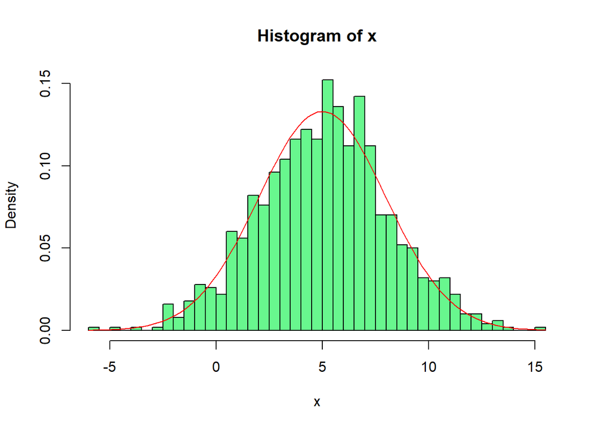

```r
x = rnorm(n= 1000, mean = 5, sd = 3)
hist(x, probability = T, breaks = 50, col = '#68f78e')
curve(dnorm(x,5,3), col = 'red', add = T)
```

#### 2. With the pisos dataset and using an only pipeline, compute the following transformations:

##### a) Drop the duplicated individuals and compute the mean value of the fats (“Valor”) by district (“Dist”).

```r
BcnPisosMeanbyDist = BcnPisos %>% extract() %>% unique(.) %$% aggregate(Valor ~ Dist, FUN = mean )

colnames(BcnPisosMeanbyDist)[2] = "Valor_medio"
```

```r
print(BcnPisosMeanbyDist)
```

```
##            Dist Valor_medio
## 1  Ciutat_Vella    11523408
## 2      Eixample    21861301
## 3        Gracia    17401416
## 4         Horta    15769832
## 5     Les_Corts    28754475
## 6    Nou_Barris    13352474
## 7   Sant_Andreu    15365746
## 8    Sant_Marti    15117212
## 9         Sants    15598655
## 10       Sarria    33022471
```

##### b) Drop the duplicated individuals, get the numeric features of the dataset and standardize it.

```r
BcnPisosScaled = BcnPisos %>% extract(,1:5,9) %>% unique(.) %>% scale(.,center = T, scale = F)

head(BcnPisosScaled)
```

```
##       Valor     Superf       Dorm      Banys      Edat
## 1 -12833143 -52.322365 -0.8972877 -0.3201423  29.28635
## 2 -10794523 -41.732365 -1.8972877 -0.3201423  59.28635
## 3  -9512323 -41.252365 -0.8972877 -0.3201423  39.28635
## 4  -7547923 -22.732365  0.1027123 -0.3201423  59.28635
## 5   1770797  12.267635 -0.8972877  0.6798577 -40.71365
## 6  -8220275  -7.432365 -0.8972877 -0.3201423  72.28635
```

##### c) Drop the duplicated individuals, add a new factor to the dataset “Greater than is mean”with values (Y,N) indicating if the Value (“Valor”) of the at is greater or not than the mean of the flats in the district.

```r
BcnPisosUniqueMeans = BcnPisos %>% unique(.) %>% left_join(., BcnPisosMeanbyDist, by = 'Dist') %>% mutate("Greater than is mean" = if_else(Valor > Valor_medio, "Yes", "No"))

head(BcnPisosUniqueMeans)
```

```
##      Valor Superf Dorm Banys Edat Estat Planta         Dist    ValSol Tipus
## 1  4962780  31.41    2     1   70  1_MM Planta Ciutat_Vella 113322.15  MANZ
## 2  7001400  42.00    1     1  100   2_M Planta Ciutat_Vella  89407.53  MANZ
## 3  8283600  42.48    2     1   80   2_M Planta Ciutat_Vella 122622.28  MANZ
## 4 10248000  61.00    3     1  100  1_MM Planta Ciutat_Vella 105350.61  MANZ
## 5 19566720  96.00    2     2    0  5_MB Planta Ciutat_Vella  86750.35  MANZ
## 6  9575648  76.30    2     1  113  1_MM   Atic Ciutat_Vella  73464.45  MANZ
##   Ascens ExtInt   Reforma Valor_medio Greater than is mean
## 1     NO    EXT  REF15-20    11523408                   No
## 2     NO    EXT    REF1A5    11523408                   No
## 3     NO    EXT RECIENREF    11523408                   No
## 4     SI    EXT RECIENREF    11523408                   No
## 5     SI    EXT OBRANUEVA    11523408                  Yes
## 6     NO    EXT  REF10-15    11523408                   No
```

#### 3. Finally, you are asked to do a complete transformation of the pisos dataset.

#### We want to analyse and visualize some general features of the districts of the city, characterizing a sample of flats.

##### a) Propose R code for the transformation of this dataset. You are free to use any technique explained during the course (and others) but the use of some pipes will be valued positively (7 points).

```r
bigIf = function (x) {
  if_else(x$variable == "Valor", "Valor",
          if_else(x$variable == "Superf", "Superf",
                  if_else((x$variable == "Dorm" & x$value == 1), "1 Dorm",
                          if_else((x$variable == "Dorm" & x$value == 2), "2 Dorm",
                                  if_else((x$variable == "Dorm" & x$value == 3), "3 Dorm",
                                          if_else((x$variable == "Dorm" & x$value == 4), "4 Dorm",
                                                  if_else((x$variable == "Dorm" & x$value == 5), "5 Dorm",
                                                          if_else((x$variable == "Ascens" & x$value == "SI"), "AscS",
                                                                  if_else((x$variable == "Ascens" & x$value == "NO"), "AscN",
                                                                          if_else((x$variable == "Planta" & x$value == "Atic"), "Atics",
                                                                                  if_else((x$variable == "Planta" & x$value == "Planta"), "Plantas",
                                                                                          if_else((x$variable == "Planta" & x$value == "Bajos"), "Bajos",
                                                                                                  if_else((x$variable == "Edat" & as.integer(x$value) <= 10), "Nous",
                                                                                                          if_else((x$variable == "Edat" & as.integer(x$value) >= 11 & as.integer(x$value) <= 20), "SemiNous",
                                                                                                                  if_else((x$variable == "Edat" & as.integer(x$value) >= 21 & as.integer(x$value) <= 50), "Vells",
                                                                                                                          if_else((x$variable == "Edat" & as.integer(x$value) >= 51), "MoltVells",
                                                                                                                                  "0 Unused Variables"
                                                                          ))))))))))))))))

}
```

```r
library(reshape2)

BcnPisosTransform = BcnPisos[,c(1:3,5,7:8,11)] %>% unique(.)  %>% melt(., id.vars = "Dist") %>% mutate("sub_variable" = bigIf(.))
library(tidyr)
BcnPisosToMean = BcnPisosTransform[BcnPisosTransform$sub_variable == c("Valor","Superf"),] %>% .[,c(1,3,4)] %>% transform(., value = as.numeric(value)) %>% pivot_wider(names_from = sub_variable, values_from = value, values_fn = mean)


BcnPisosToCount = BcnPisosTransform[!(BcnPisosTransform$sub_variable %in% c("Valor","Superf")),] %>% .[,c(1,4)] %>% mutate("countObs" = 1) %>% pivot_wider(names_from = sub_variable, values_from = countObs, values_fn = sum, values_fill = 0, names_sort = T)

BcnSummary = full_join(BcnPisosToMean, BcnPisosToCount, by = "Dist")


print(BcnSummary)
```

```
## # A tibble: 10 × 17
##    Dist   Valor Superf 1 Dor…¹ 2 Dor…² 3 Dor…³ 4 Dor…⁴ 5 Dor…⁵  AscN  AscS Atics
##    <chr>  <dbl>  <dbl>   <dbl>   <dbl>   <dbl>   <dbl>   <dbl> <dbl> <dbl> <dbl>
##  1 Ciut… 1.15e7   67.5      51      67      53      13       3   151    36    23
##  2 Sant… 1.54e7   80.7      16      70     187      51       1   116   209    20
##  3 Sants 1.55e7   78.1      23      70     164      59       1    95   222    33
##  4 Eixa… 2.18e7   94.7      24      63     126     125      29    84   283    33
##  5 Sarr… 3.22e7  112.       15      21      45      50      22    22   131    16
##  6 Grac… 1.72e7   82.9      13      41      68      34       6    81    81    12
##  7 Horta 1.67e7   81.6      12      52     139      45       1   138   111    42
##  8 Les_… 2.78e7  102.        1      13      33      31       5    15    68     8
##  9 Nou_… 1.32e7   73.4       6      65     127      25       0   117   106    42
## 10 Sant… 1.47e7   77.3      11      32     106      35       1    64   121    18
## # … with 6 more variables: Bajos <dbl>, MoltVells <dbl>, Nous <dbl>,
## #   Plantas <dbl>, SemiNous <dbl>, Vells <dbl>, and abbreviated variable names
## #   ¹`1 Dorm`, ²`2 Dorm`, ³`3 Dorm`, ⁴`4 Dorm`, ⁵`5 Dorm`
```